# GAN 기초

## pytorch를 왜 써야하는가

```python
import torch
```

파이토치에서는 일반적인 파이썬과 다르게 tensor라는 변수 지정 방식이 존재한다.

x1, x2가 tensor 형태의 변수이다.

```python
x1 = torch.tensor(3.9, requires_grad = True) #파이토치의 변수 저장방법 : tensor
x2 = torch.tensor(2.3, requires_grad = True) # requires_grad = True : 해당변수에 대해 기울기 계산 go!

y = x1**2 + 3

z = (y-1)*(y**2-10)

print(y)
print(z) #예상하듯이 대입한 값이 도출된다.
```

```
tensor(18.2100, grad_fn=<AddBackward0>)
tensor(5534.8071, grad_fn=<MulBackward0>)
```

```python
z.backward() #x tensor에 대해서 z를 미분하여 저장하겠다(x tensor에)
print(x1.grad)
```

```
tensor(7397.4609)
```

```python
#예상해보자
print(x2.grad)
```

```
None
```

예상과 다르게 나온 이유는 y = x1**2 + 3으로 x1을 tensor로 가지고 있기에!

y = x2**2 +3으로 바꿔주면 x2 tensor에 대한 값이 나온다

```python
y.backward()
print(x1.grad)
```

[output not shown]

오류가 발생한다.

다른 함수를 통해서는 동시에 가능하지만, backward함수를 통해서는 동시에 기울기 계산 X

### pytorch의 주요기능!

⭐️기울기를 위한 계산을 자동으로 해준다.

딥러닝 알고리즘을 실행시, 기울기 계산은 불가피하다. 이러한 pytorch는 계산 그래프를 통해 tensor끼리의(x, y, z) 연결관계를 구성하여 기울기를 계산해준다. pytorch가 z에 대한 기울기를 구할때는 x에 대한 y의 기울기, y에 대한 z의 기울기를 구하는식의 체인룰(Chain Rule)을 사용한다.

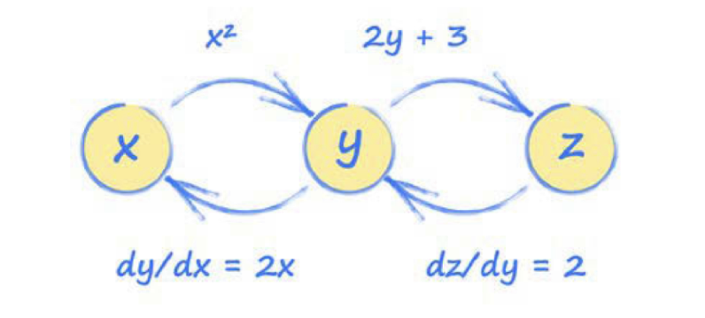

#### [tensor간의 관계를 나타내는 계산 그래프]

### pytorch의 이외 기능(?) 소개

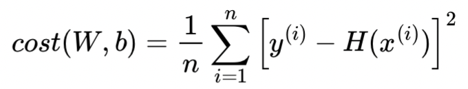

#### [선형회귀 손실함수]

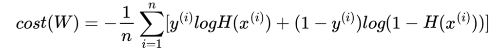

#### [로지스틱 회귀 손실함수]

# 핵심정리

1. 구글의 코랩은 구글의 인프라에서 파이썬이 돌아가도록 지원한다. 그래서 인터넷만 연결된 환경이라면 웹에서 코딩을 할 수 있다.
2. pytorch는 파이썬 기반의 머신러닝 프레임워크로 머신러닝을 쉽게해줄 함수와 행렬연산에 유용하다.
3. pytorch의 기본 데이터 형태는 tensor이다.행렬,리스트,값..등이 될 수 있다.
4. pytorch의 주요기능은 기울기를 자동계산 해준다는거다. 신경망을 훈령하기 위해서 기울기를 구하는게 필수적이다. 계산 그래프를 통해서 텐서간의 연결관계를 구성한다. pytorch는 투명하게 과정을 수행한다.